# Working With CRUD

36-350 – Statistical Computing

Week 13 – Spring 2019

# But I Don’t Like CRUD

No, no. CRUD is an acronym that stands for four basic table operations:

- **C**reate (meaning for us: `CREATE` and `INSERT`)
- **R**ead (meaning `SELECT`)
- **U**pdate (meaning `UPDATE` and `ALTER TABLE`)
- **D**elete (meaning `DROP TABLE`, `DELETE FROM`, and `ALTER TABLE`)

We will discuss the C, the U, and the D in this notes set, and the R in the next one…

# CREATE and INSERT

Assuming you do not read in a table from a previously existing file via use of ‘\i’, you’ll need to create and populate a table yourself.

The command is

```
CREATE TABLE <name>
(<column 1> <type 1> <constraint 1>, ... , <multi-column constraint(s)>);
```

(Note the semi-colon at the end. This trips up *everyone* at one time or another.)

Example (which you can cut and paste into your own Postgres session from the Rmd file):

```
CREATE TABLE products (
  product_id serial PRIMARY KEY,
  label text UNIQUE NOT NULL CHECK (char_length(label) > 0),
  price money CHECK (price >= 0::money),
  discount money DEFAULT 0.0 CHECK (discount >= 0::money),
  inventory integer DEFAULT 0 CHECK (inventory >= 0),
  CHECK (price > discount)
);
```

# CREATE and INSERT

```
CREATE TABLE products (
  product_id serial PRIMARY KEY,
  label text UNIQUE NOT NULL CHECK (char_length(label) > 0),
  price money CHECK (price >= 0::money),
  discount money DEFAULT 0::money CHECK (discount >= 0::money),
  inventory integer DEFAULT 0 CHECK (inventory >= 0),
  CHECK (price > discount)
);
```

There are many things to note here:

- First, you can see that constraints are given in the form

  ```
  CHECK (<relationship>)
  ```

- Second, after specifying the type (`text`, `money`, etc.), you can specify default values for columns, that values are to be unique (no two rows can have the same value), and that null values are not allowed.
- Third, `::` is used for casting into types (e.g., `0::money`).
- Last, we specify one column to be a sequential series of integers (via `serial`) and specify these integers to be the `primary key`.

(Remember to supplement the descriptions given here (and below) with appropriate Googling and by looking at the Postgres on-line documentation.)

# CREATE and INSERT

To populate the table one row at a time:

```
INSERT INTO <name> (<column i>,<column j>,...) VALUES
  (<value i>,<value j>,...),
  ...
  (<value i>,<value j>,...);
```

If you leave out the `(<column i>,<column j>,…)` part, then `Postgres` will simply assume that you will be entering values for all columns (in order). (If you don’t intend to enter data for all columns, be sure that the left-out columns have default values, if appropriate.) For instance:

```
INSERT INTO products VALUES
  (1,'kirk action figure',50,10,13),
  (2,'spock action figure',40,5,22);
```

```
INSERT INTO products (product_id,label,inventory) VALUES
  (3,'Scotty Dog',950);
```

To look at your table, do

```
SELECT * FROM products;
```

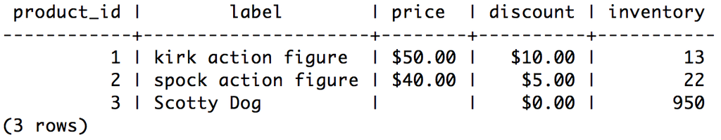

(We’ll come back to `SELECT` later.)

# UPDATE and ALTER TABLE

The `UPDATE` command allows us to modify values in table cells.

```
UPDATE <name>
   SET <column1> = <new value 1>,
   SET <column2> = <new value 2>,
   ...
   WHERE <row condition>;
```

Think of the `WHERE` as being like a call to the `which()` function in `R`: in it, you set a range of values for one of the table columns, and thereby select which rows to update.

```
UPDATE products
  SET discount = 8::money
  WHERE price >= 40::money;
```

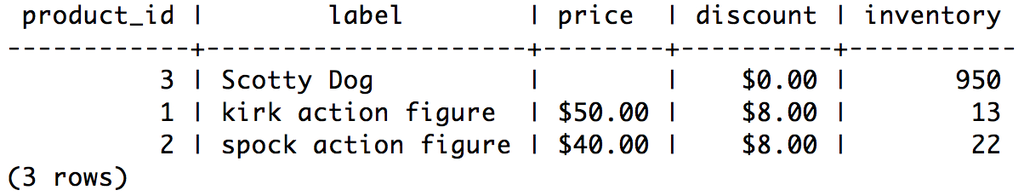

(Note what happened: the two rows that were updated moved down! The `product_id` need not be displayed in numeric order, despite being of type `SERIAL`.)

# UPDATE and ALTER TABLE

If you wish to add or delete an entire column, or rename an column, or change constraints, etc., you would “update” your table using `ALTER TABLE`:

```
ALTER TABLE <name>
  <action>;
```

There are too many possible to provide a clean shorthand for them all. Best just to give a few examples:

```
ALTER TABLE products
  ADD COLUMN rating NUMERIC CHECK (rating >= 0.0) CHECK (rating <= 5.0);

ALTER TABLE products
  ALTER COLUMN rating SET DEFAULT 4.0;

ALTER TABLE products
  RENAME COLUMN label TO type;
```

Etc.

# DROP TABLE, DELETE FROM, and ALTER TABLE

To remove an column:

```
ALTER TABLE <name>
  DROP COLUMN <column>;
```

To remove one or more entries from a table:

```
DELETE FROM <name>
  WHERE <condition>;
```

(Be careful! If you leave out the `WHERE` clause, then **all** entries are deleted.)

To remove a table in its entirety:

```
DROP TABLE <name>;
```